# German Credit Scoring

Anusha Chintakunta Manjunatha

February 19, 2018

## German Credit

### Logistic Regression

#### Exploratory Analysis

##### Exploratory Analysis

```r
str(german_credit)
```

```
## 'data.frame':    1000 obs. of  21 variables:
##  $ chk_acct        : Factor w/ 4 levels "A11","A12","A13",..: 1 2 4 1 1 4 4 2 4 2 ...
##  $ duration        : int  6 48 12 42 24 36 24 36 12 30 ...
##  $ credit_his      : Factor w/ 5 levels "A30","A31","A32",..: 5 3 5 3 4 3 3 3 3 5 ...
##  $ purpose         : Factor w/ 10 levels "A40","A41","A410",..: 5 5 8 4 1 8 4 2 5 1 ...
##  $ amount          : int  1169 5951 2096 7882 4870 9055 2835 6948 3059 5234 ...
##  $ saving_acct     : Factor w/ 5 levels "A61","A62","A63",..: 5 1 1 1 1 5 3 1 4 1 ...
##  $ present_emp     : Factor w/ 5 levels "A71","A72","A73",..: 5 3 4 4 3 3 5 3 4 1 ...
##  $ installment_rate: int  4 2 2 2 3 2 3 2 2 4 ...
##  $ sex             : Factor w/ 4 levels "A91","A92","A93",..: 3 2 3 3 3 3 3 3 1 4 ...
##  $ other_debtor    : Factor w/ 3 levels "A101","A102",..: 1 1 1 3 1 1 1 1 1 1 ...
##  $ present_resid   : int  4 2 3 4 4 4 4 2 4 2 ...
##  $ property        : Factor w/ 4 levels "A121","A122",..: 1 1 1 2 4 4 2 3 1 3 ...
##  $ age             : int  67 22 49 45 53 35 53 35 61 28 ...
##  $ other_install   : Factor w/ 3 levels "A141","A142",..: 3 3 3 3 3 3 3 3 3 3 ...
##  $ housing         : Factor w/ 3 levels "A151","A152",..: 2 2 2 3 3 3 2 1 2 2 ...
##  $ n_credits       : int  2 1 1 1 2 1 1 1 1 2 ...
##  $ job             : Factor w/ 4 levels "A171","A172",..: 3 3 2 3 3 2 3 4 2 4 ...
##  $ n_people        : int  1 1 2 2 2 2 1 1 1 1 ...
##  $ telephone       : Factor w/ 2 levels "A191","A192": 2 1 1 1 1 2 1 2 1 1 ...
##  $ foreign         : Factor w/ 2 levels "A201","A202": 1 1 1 1 1 1 1 1 1 1 ...
##  $ response        : Factor w/ 2 levels "0","1": 1 2 1 1 2 1 1 1 1 2 ...
```

```r
summary(german_credit)
```

```
##  chk_acct     duration    credit_his    purpose        amount
##  A11:274   Min.   : 4.0   A30: 40    A43    :280   Min.   :  250
##  A12:269   1st Qu.:12.0   A31: 49    A40    :234   1st Qu.: 1366
##  A13: 63   Median :18.0   A32:530    A42    :181   Median : 2320
##  A14:394   Mean   :20.9   A33: 88    A41    :103   Mean   : 3271
##            3rd Qu.:24.0   A34:293    A49    : 97   3rd Qu.: 3972
##            Max.   :72.0              A46    : 50   Max.   :18424
##                                      (Other): 55
##  saving_acct present_emp installment_rate  sex      other_debtor
##  A61:603     A71: 62     Min.   :1.000    A91: 50   A101:907
##  A62:103     A72:172     1st Qu.:2.000    A92:310   A102: 41
##  A63: 63     A73:339     Median :3.000    A93:548   A103: 52
##  A64: 48     A74:174     Mean   :2.973    A94: 92
##  A65:183     A75:253     3rd Qu.:4.000
##                          Max.   :4.000
##
##  present_resid   property        age        other_install housing
##  Min.   :1.000   A121:282   Min.   :19.00   A141:139      A151:179
##  1st Qu.:2.000   A122:232   1st Qu.:27.00   A142: 47      A152:713
##  Median :3.000   A123:332   Median :33.00   A143:814      A153:108
##  Mean   :2.845   A124:154   Mean   :35.55
##  3rd Qu.:4.000              3rd Qu.:42.00
##  Max.   :4.000              Max.   :75.00
##
##    n_credits       job         n_people     telephone  foreign    response
##  Min.   :1.000   A171: 22   Min.   :1.000   A191:596   A201:963   0:700
##  1st Qu.:1.000   A172:200   1st Qu.:1.000   A192:404   A202: 37   1:300
##  Median :1.000   A173:630   Median :1.000
##  Mean   :1.407   A174:148   Mean   :1.155
##  3rd Qu.:2.000              3rd Qu.:1.000
##  Max.   :4.000              Max.   :2.000
##
```

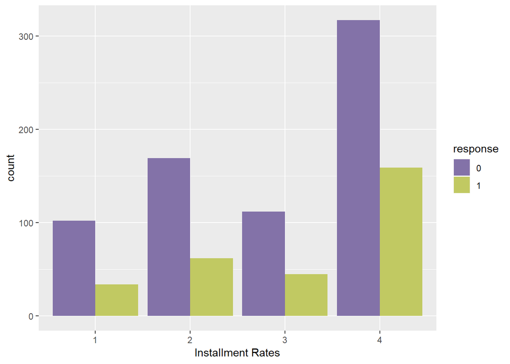

```r
## Installment Rate

ggplot(german_credit, aes(factor(installment_rate), ..count..)) +
 geom_bar(aes(fill = response), position = "dodge") + xlab("Installment Rates") +
  scale_fill_manual(values = c("#8372A8", "#C1C962"))
```

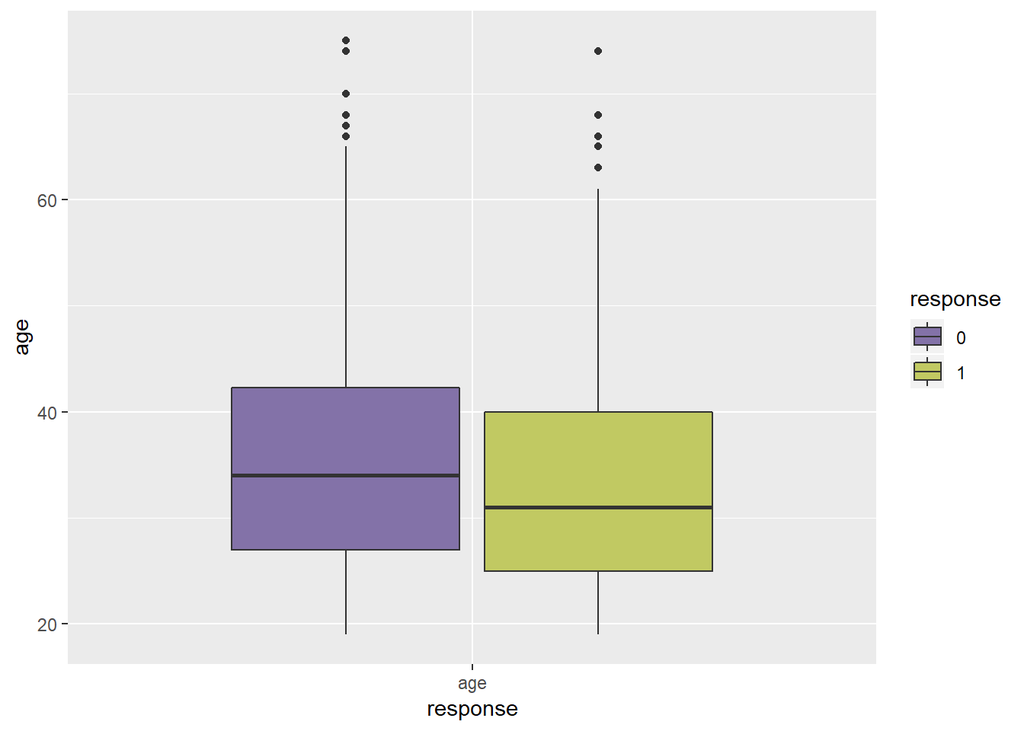

```r
# Age

ggplot(melt(german_credit[,c(13,21)]), aes(x = variable, y = value, fill = response)) +
geom_boxplot() + xlab("response") + ylab("age") +
  scale_fill_manual(values = c("#8372A8", "#C1C962"))
```

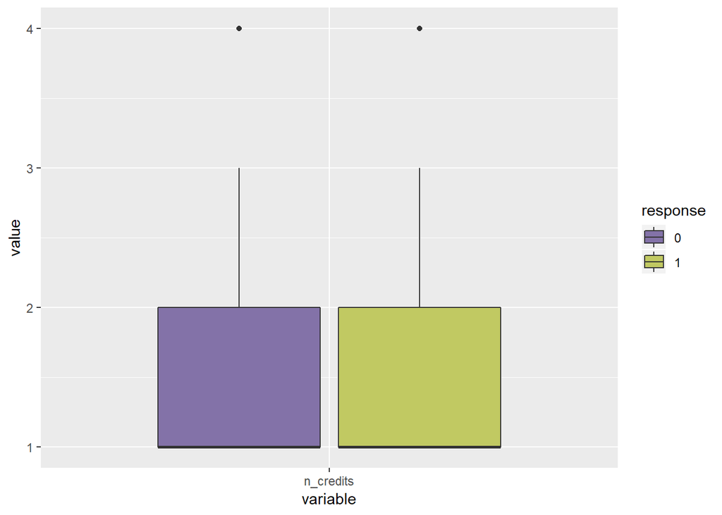

```r
# n_credits

ggplot(melt(german_credit[,c(16,21)]), aes(x = variable, y = value, fill = response)) +
  geom_boxplot() +
  scale_fill_manual(values = c("#8372A8", "#C1C962"))
```

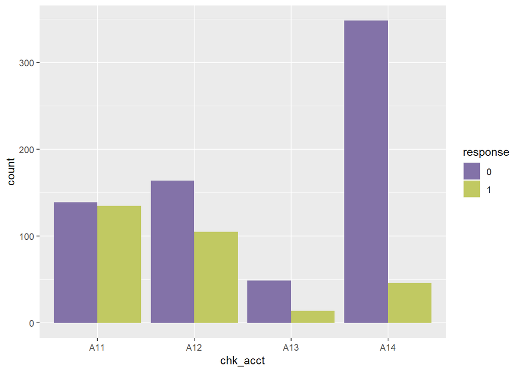

```r
# chk_acct

ggplot(german_credit, aes(chk_acct, ..count..)) +
  geom_bar(aes(fill = response), position = "dodge") +
  scale_fill_manual(values = c("#8372A8", "#C1C962"))
```

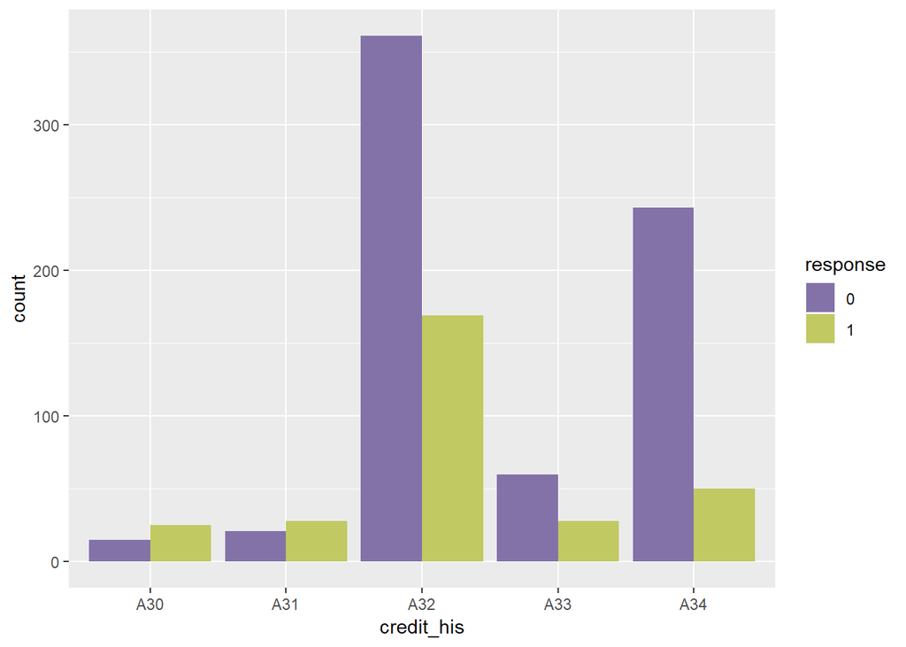

```r
# credit_his

ggplot(german_credit, aes(credit_his, ..count..)) +
  geom_bar(aes(fill = response), position = "dodge") +
  scale_fill_manual(values = c("#8372A8", "#C1C962"))
```

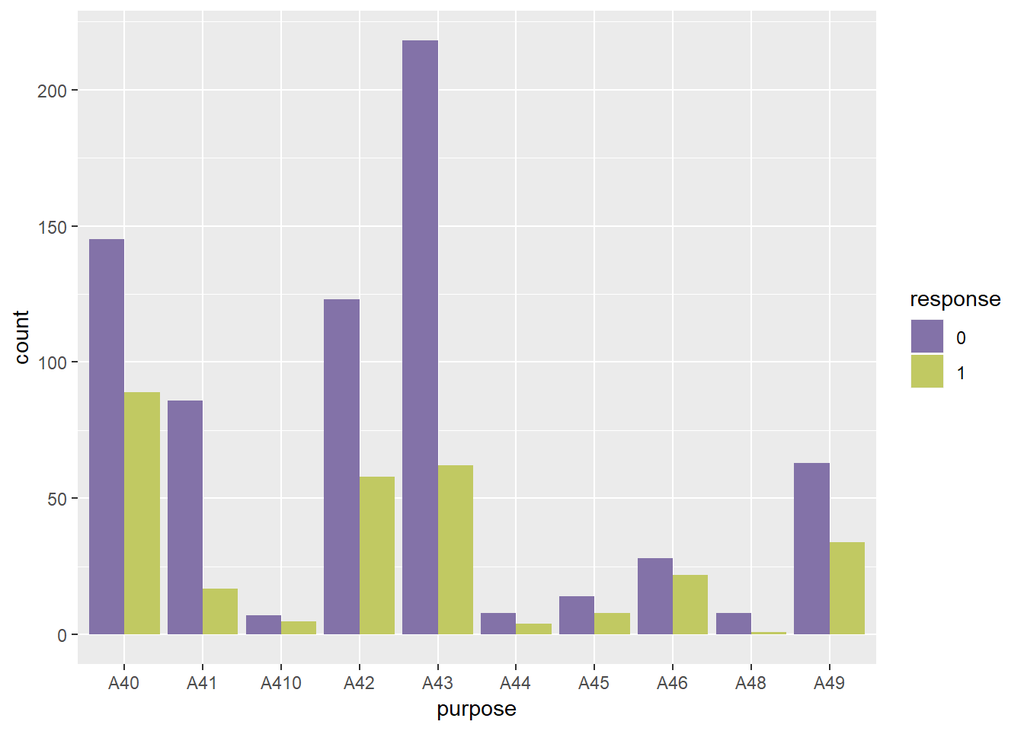

```r
# purpose

ggplot(german_credit, aes(purpose, ..count..)) +
  geom_bar(aes(fill = response), position = "dodge") +
  scale_fill_manual(values = c("#8372A8", "#C1C962"))
```

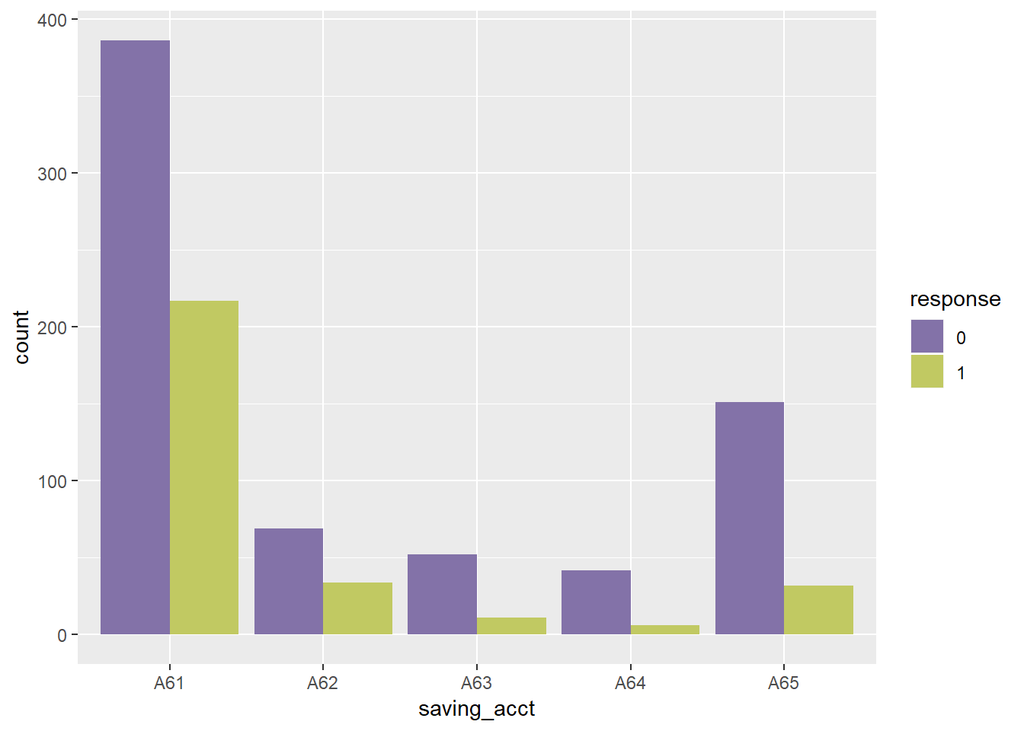

```r
# saving_acct

ggplot(german_credit, aes(saving_acct, ..count..)) +
  geom_bar(aes(fill = response), position = "dodge") +
  scale_fill_manual(values = c("#8372A8", "#C1C962"))
```

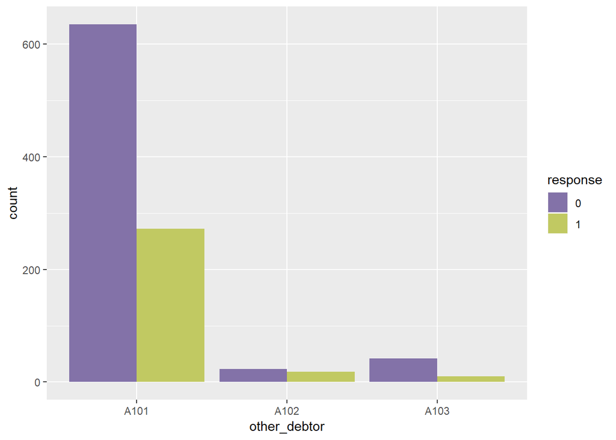

```r
# other_debtor

ggplot(german_credit, aes(other_debtor, ..count..)) +
  geom_bar(aes(fill = response), position = "dodge") +
  scale_fill_manual(values = c("#8372A8", "#C1C962"))
```

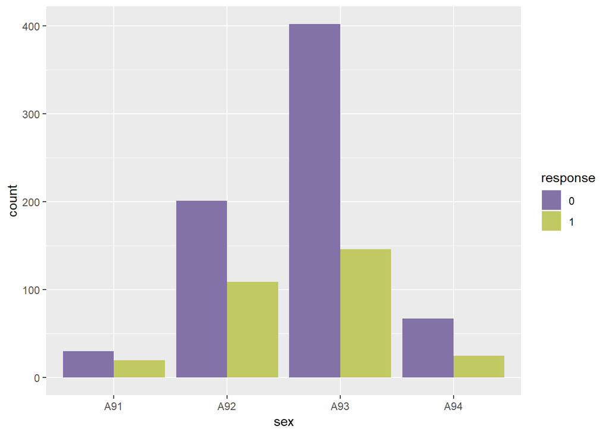

```r
# sex

ggplot(german_credit, aes(sex, ..count..)) +
  geom_bar(aes(fill = response), position = "dodge") +
  scale_fill_manual(values = c("#8372A8", "#C1C962"))
```

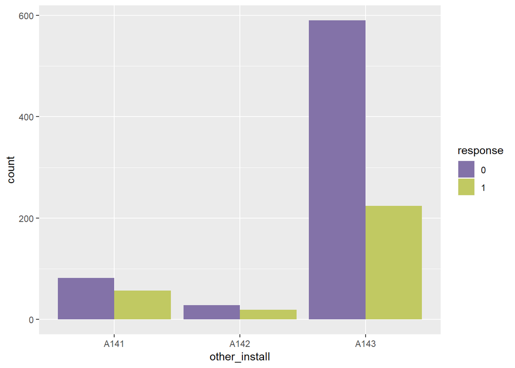

```r
# other install

ggplot(german_credit, aes(other_install, ..count..)) +
  geom_bar(aes(fill = response), position = "dodge") +
  scale_fill_manual(values = c("#8372A8", "#C1C962"))
```

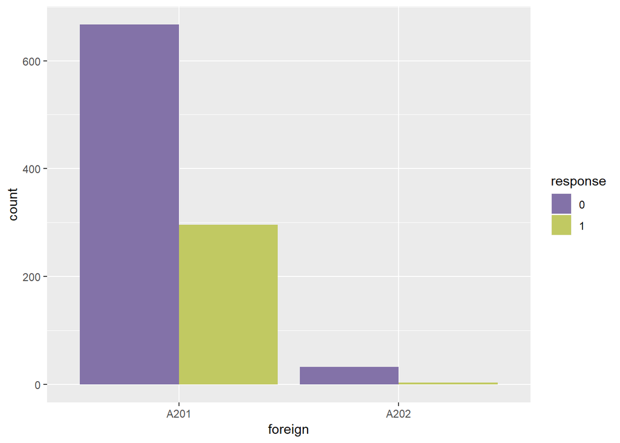

```r
# foreign

ggplot(german_credit, aes(foreign, ..count..)) +
  geom_bar(aes(fill = response), position = "dodge") +
  scale_fill_manual(values = c("#8372A8", "#C1C962"))
```

#### Logit, Probit and Cloglog

##### Comparison of Logit, Probit and Cloglog

```r
rows <- sample(nrow(german_credit))
german_credit_randomized <- german_credit[rows, ]

split_german_credit <- round(nrow(german_credit_randomized)*0.75)
train_german_credit <- german_credit_randomized[1:split_german_credit, ]
test_german_credit <- german_credit_randomized[(split_german_credit + 1):nrow(german_credit_randomized), ]
```

For logit model, **BIC** came out to be 1017.82 For probit model, BIC came out to be 1016.63 And, for cloglog model, BIC came out to be 1015.46

##### Logit Model

```r
null_log <- glm(formula = response~1, family = "binomial", data = train_german_credit)
full_log <- glm(formula = response ~ . , family = "binomial",
                data = train_german_credit)

summary(full_log)
```

```
##
## Call:
## glm(formula = response ~ ., family = "binomial", data = train_german_credit)
##
## Deviance Residuals:
##     Min       1Q   Median       3Q      Max
## -2.0764  -0.7138  -0.3931   0.7203   2.4910
##
## Coefficients:
##                     Estimate Std. Error z value Pr(>|z|)
## (Intercept)       -7.711e-01  1.233e+00  -0.625  0.53180
## chk_acctA12       -4.136e-01  2.548e-01  -1.623  0.10459
## chk_acctA13       -9.493e-01  4.092e-01  -2.320  0.02035 *
## chk_acctA14       -1.695e+00  2.626e-01  -6.454 1.09e-10 ***
## duration           2.576e-02  1.102e-02   2.338  0.01939 *
## credit_hisA31      4.822e-01  6.214e-01   0.776  0.43771
## credit_hisA32     -4.181e-01  4.735e-01  -0.883  0.37721
## credit_hisA33     -1.099e+00  5.431e-01  -2.024  0.04298 *
## credit_hisA34     -1.440e+00  4.831e-01  -2.980  0.00288 **
## purposeA41        -2.021e+00  4.548e-01  -4.444 8.82e-06 ***
## purposeA410       -1.912e+00  1.011e+00  -1.891  0.05859 .
## purposeA42        -7.281e-01  2.949e-01  -2.469  0.01353 *
## purposeA43        -6.425e-01  2.774e-01  -2.316  0.02053 *
## purposeA44        -7.444e-02  8.880e-01  -0.084  0.93319
## purposeA45        -6.122e-02  6.009e-01  -0.102  0.91886
## purposeA46         3.119e-01  4.478e-01   0.696  0.48615
## purposeA48        -2.125e+00  1.224e+00  -1.736  0.08264 .
## purposeA49        -6.586e-01  3.869e-01  -1.702  0.08875 .
## amount             1.141e-04  5.274e-05   2.163  0.03050 *
## saving_acctA62     1.497e-02  3.298e-01   0.045  0.96380
## saving_acctA63    -2.506e-01  4.375e-01  -0.573  0.56671
## saving_acctA64    -7.828e-01  5.740e-01  -1.364  0.17266
## saving_acctA65    -5.563e-01  2.973e-01  -1.871  0.06134 .
## present_empA72    -3.733e-01  5.062e-01  -0.737  0.46089
## present_empA73    -3.436e-01  4.819e-01  -0.713  0.47578
## present_empA74    -1.129e+00  5.255e-01  -2.147  0.03176 *
## present_empA75    -6.814e-01  5.007e-01  -1.361  0.17356
## installment_rate   2.908e-01  9.883e-02   2.942  0.00326 **
## sexA92            -1.267e-01  4.368e-01  -0.290  0.77182
## sexA93            -6.055e-01  4.342e-01  -1.394  0.16319
```

[output cut: 14 more lines]

```
## jobA173            8.205e-01  7.662e-01   1.071  0.28427
## jobA174            8.639e-01  7.846e-01   1.101  0.27089
## n_people           4.322e-01  2.843e-01   1.520  0.12840
## telephoneA192     -3.449e-01  2.258e-01  -1.528  0.12658
## foreignA202       -1.214e+00  6.325e-01  -1.920  0.05486 .
## ---
## Signif. codes:  0 '***' 0.001 '**' 0.01 '*' 0.05 '.' 0.1 ' ' 1
##
## (Dispersion parameter for binomial family taken to be 1)
##
##     Null deviance: 932.61  on 749  degrees of freedom
## Residual deviance: 693.44  on 701  degrees of freedom
## AIC: 791.44
##
## Number of Fisher Scoring iterations: 5
```

```r
AIC(full_log)
```

```
## [1] 791.4415
```

```r
BIC(full_log)
```

```
## [1] 1017.825
```

##### Probit Model

```r
full_probit <- glm(formula = response ~ . , family = binomial(link = "probit"),
                   data = train_german_credit)

summary(full_probit)
```

```
##
## Call:
## glm(formula = response ~ ., family = binomial(link = "probit"),
##     data = train_german_credit)
##
## Deviance Residuals:
##     Min       1Q   Median       3Q      Max
## -1.9741  -0.7236  -0.3761   0.7323   2.5157
##
## Coefficients:
##                     Estimate Std. Error z value Pr(>|z|)
## (Intercept)       -5.133e-01  7.258e-01  -0.707   0.4794
## chk_acctA12       -2.451e-01  1.504e-01  -1.629   0.1032
## chk_acctA13       -5.290e-01  2.384e-01  -2.219   0.0265 *
## chk_acctA14       -1.009e+00  1.503e-01  -6.715 1.88e-11 ***
## duration           1.491e-02  6.424e-03   2.321   0.0203 *
## credit_hisA31      3.161e-01  3.653e-01   0.865   0.3869
## credit_hisA32     -2.326e-01  2.791e-01  -0.833   0.4046
## credit_hisA33     -6.244e-01  3.184e-01  -1.961   0.0499 *
## credit_hisA34     -8.332e-01  2.836e-01  -2.938   0.0033 **
## purposeA41        -1.203e+00  2.575e-01  -4.672 2.98e-06 ***
## purposeA410       -1.220e+00  5.921e-01  -2.061   0.0393 *
## purposeA42        -4.257e-01  1.724e-01  -2.469   0.0135 *
## purposeA43        -3.717e-01  1.607e-01  -2.312   0.0208 *
## purposeA44        -5.621e-02  5.088e-01  -0.110   0.9120
## purposeA45        -1.260e-02  3.552e-01  -0.035   0.9717
## purposeA46         1.816e-01  2.633e-01   0.690   0.4904
## purposeA48        -1.253e+00  6.776e-01  -1.849   0.0645 .
## purposeA49        -3.683e-01  2.242e-01  -1.643   0.1004
## amount             6.655e-05  3.081e-05   2.160   0.0308 *
## saving_acctA62    -4.705e-04  1.922e-01  -0.002   0.9980
## saving_acctA63    -1.659e-01  2.456e-01  -0.675   0.4994
## saving_acctA64    -4.448e-01  3.243e-01  -1.371   0.1703
## saving_acctA65    -3.093e-01  1.688e-01  -1.832   0.0669 .
## present_empA72    -2.231e-01  2.983e-01  -0.748   0.4546
## present_empA73    -1.943e-01  2.841e-01  -0.684   0.4941
## present_empA74    -6.584e-01  3.075e-01  -2.141   0.0323 *
## present_empA75    -4.062e-01  2.941e-01  -1.381   0.1672
## installment_rate   1.687e-01  5.740e-02   2.938   0.0033 **
## sexA92            -6.066e-02  2.582e-01  -0.235   0.8143
```

[output cut: 15 more lines]

```
## jobA173            5.219e-01  4.489e-01   1.163   0.2450
## jobA174            5.597e-01  4.596e-01   1.218   0.2234
## n_people           2.473e-01  1.658e-01   1.492   0.1357
## telephoneA192     -2.022e-01  1.301e-01  -1.554   0.1201
## foreignA202       -7.138e-01  3.580e-01  -1.994   0.0462 *
## ---
## Signif. codes:  0 '***' 0.001 '**' 0.01 '*' 0.05 '.' 0.1 ' ' 1
##
## (Dispersion parameter for binomial family taken to be 1)
##
##     Null deviance: 932.61  on 749  degrees of freedom
## Residual deviance: 692.26  on 701  degrees of freedom
## AIC: 790.26
##
## Number of Fisher Scoring iterations: 6
```

```r
AIC(full_probit)
```

```
## [1] 790.2556
```

```r
BIC(full_probit)
```

```
## [1] 1016.639
```

##### Complimentary Log Log Model

```r
full_cloglog <- glm(formula = response ~ . , family = binomial(link = "cloglog"),
                   data = train_german_credit)

summary(full_cloglog)
```

```
##
## Call:
## glm(formula = response ~ ., family = binomial(link = "cloglog"),
##     data = train_german_credit)
##
## Deviance Residuals:
##     Min       1Q   Median       3Q      Max
## -1.9386  -0.7100  -0.4134   0.6267   2.3699
##
## Coefficients:
##                     Estimate Std. Error z value Pr(>|z|)
## (Intercept)       -1.348e+00  9.318e-01  -1.446 0.148123
## chk_acctA12       -2.955e-01  1.826e-01  -1.618 0.105561
## chk_acctA13       -7.712e-01  3.339e-01  -2.310 0.020891 *
## chk_acctA14       -1.320e+00  2.053e-01  -6.433 1.25e-10 ***
## duration           2.029e-02  7.812e-03   2.597 0.009398 **
## credit_hisA31      4.344e-01  3.998e-01   1.086 0.277259
## credit_hisA32     -2.592e-01  3.148e-01  -0.823 0.410375
## credit_hisA33     -8.085e-01  3.805e-01  -2.125 0.033591 *
## credit_hisA34     -1.076e+00  3.324e-01  -3.238 0.001202 **
## purposeA41        -1.578e+00  3.627e-01  -4.351 1.36e-05 ***
## purposeA410       -1.838e+00  8.044e-01  -2.285 0.022334 *
## purposeA42        -5.545e-01  2.148e-01  -2.581 0.009852 **
## purposeA43        -4.943e-01  2.042e-01  -2.421 0.015479 *
## purposeA44        -1.042e-01  5.711e-01  -0.183 0.855188
## purposeA45        -8.930e-02  4.455e-01  -0.200 0.841134
## purposeA46         1.932e-01  3.142e-01   0.615 0.538564
## purposeA48        -1.738e+00  1.056e+00  -1.646 0.099769 .
## purposeA49        -5.917e-01  2.840e-01  -2.084 0.037177 *
## amount             8.381e-05  3.810e-05   2.200 0.027828 *
## saving_acctA62     9.048e-02  2.379e-01   0.380 0.703661
## saving_acctA63    -4.024e-01  3.716e-01  -1.083 0.278885
## saving_acctA64    -6.753e-01  4.559e-01  -1.481 0.138541
## saving_acctA65    -4.681e-01  2.353e-01  -1.989 0.046702 *
## present_empA72    -3.351e-01  3.496e-01  -0.959 0.337768
## present_empA73    -2.418e-01  3.308e-01  -0.731 0.464923
## present_empA74    -8.875e-01  3.708e-01  -2.394 0.016687 *
## present_empA75    -5.124e-01  3.522e-01  -1.455 0.145728
## installment_rate   2.556e-01  7.432e-02   3.439 0.000584 ***
## sexA92            -1.262e-01  3.149e-01  -0.401 0.688646
```

[output cut: 15 more lines]

```
## jobA173            7.767e-01  5.794e-01   1.341 0.180059
## jobA174            7.373e-01  5.973e-01   1.234 0.217047
## n_people           3.815e-01  2.126e-01   1.795 0.072688 .
## telephoneA192     -2.386e-01  1.689e-01  -1.413 0.157789
## foreignA202       -8.874e-01  5.271e-01  -1.684 0.092253 .
## ---
## Signif. codes:  0 '***' 0.001 '**' 0.01 '*' 0.05 '.' 0.1 ' ' 1
##
## (Dispersion parameter for binomial family taken to be 1)
##
##     Null deviance: 932.61  on 749  degrees of freedom
## Residual deviance: 691.08  on 701  degrees of freedom
## AIC: 789.08
##
## Number of Fisher Scoring iterations: 16
```

```r
AIC(full_cloglog)
```

```
## [1] 789.0764
```

```r
BIC(full_cloglog)
```

```
## [1] 1015.46
```

#### Insample Prediction

##### Stepwise Selection and Insample Prediction

##### Stepwise Selection

```r
stepwise_AICmodel <- step(full_log,direction = "both")

stepwise_BICmodel <- step(full_log,direction = "both", k = log(nrow(train_german_credit)))
```

Variables selected after applying Stepwise AIC are chk_acct, duration, credit_his, purpose, amount, present_emp, installment_rate, sex, other_debtor, other_install, n_credits, n_people and foreign

**AIC** is 778.2989039

Variables selected after applying Stepwise BIC are chk_acct and duration

**BIC** is 852.5304001

##### LASSO Selection

```r
dummy <- model.matrix(~., data = german_credit) #converting data to numeric matrix
dummy <- dummy[,-1]
nrow(german_credit)
```

```
## [1] 1000
```

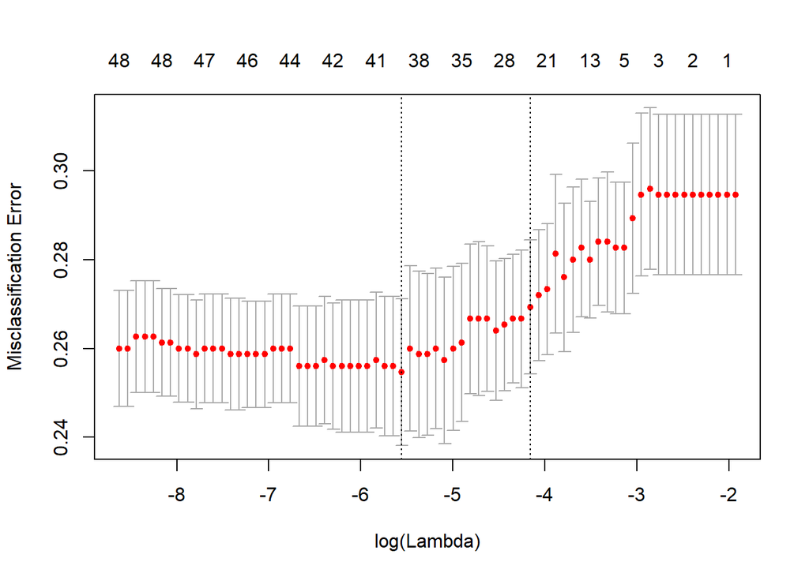

```r
rows_dummy <- sample(nrow(dummy))
dummy_randomized <- dummy[rows_dummy, ]

split_dummy <- round(nrow(dummy_randomized)*0.75)
train_dummy <- dummy_randomized[1:split_dummy, ]
test_dummy <- dummy_randomized[(split_dummy + 1):nrow(dummy_randomized), ]


credit_lasso <- cv.glmnet(x = as.matrix(train_dummy[,-49]), y = train_dummy[,49],
                          family = "binomial", type.measure = "class", alpha = 1)




plot(credit_lasso)
```

```r
coef(credit_lasso, credit_lasso$lambda.min)
```

```
## 49 x 1 sparse Matrix of class "dgCMatrix"
##                               1
## (Intercept)       -0.5613264252
## chk_acctA12       -0.1420174360
## chk_acctA13       -0.6622696525
## chk_acctA14       -1.4872929361
## duration           0.0206773121
## credit_hisA31      0.5067554283
## credit_hisA32     -0.1705706879
## credit_hisA33     -0.3736114895
## credit_hisA34     -1.2091923212
## purposeA41        -1.0111826105
## purposeA410       -0.8213943124
## purposeA42        -0.4842731717
## purposeA43        -0.6815762862
## purposeA44         0.0020436481
## purposeA45         .
## purposeA46         0.0819945789
## purposeA48        -1.0366689351
## purposeA49        -0.2324811942
## amount             0.0001184591
## saving_acctA62    -0.5223704470
## saving_acctA63    -0.6220660805
## saving_acctA64    -1.0229609816
## saving_acctA65    -0.7526951004
## present_empA72     0.2154133169
## present_empA73     .
## present_empA74    -0.3740548135
## present_empA75     .
## installment_rate   0.2376622322
## sexA92             .
## sexA93            -0.4153892160
## sexA94             0.0078418519
## other_debtorA102   0.3058138572
## other_debtorA103  -0.8905784569
## present_resid      .
## propertyA122       0.1741980172
## propertyA123       0.0828950145
## propertyA124       0.4542421897
## age               -0.0103108439
## other_installA142  .
## other_installA143 -0.0786072726
## housingA152       -0.2152687022
## housingA153       -0.3380414897
## n_credits          0.2165851270
## jobA172            .
## jobA173            0.0941302125
## jobA174            .
## n_people           0.1511730774
## telephoneA192     -0.1738092064
## foreignA202       -0.7650523339
```

Variables selected for in sample prediction are based on Stepwise AIC model.

##### In Sample Selection

The logistic model has been fitted based on the variable selected from the above the step, The ROC curve is plotted and the area under the curve was found to be 0.8182. The misclassification rate (false negative rate) is calculated to be 0.221.

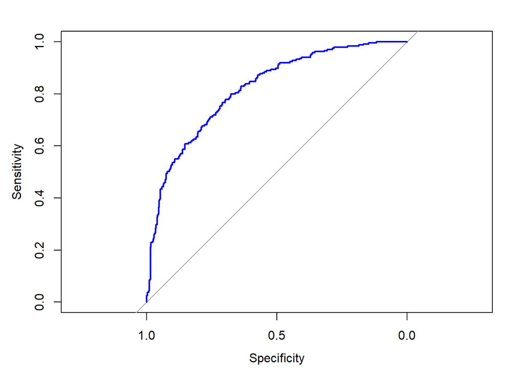

```r
best_insample <- glm(formula = response ~ chk_acct + duration + credit_his + purpose + amount + present_emp + installment_rate + sex + other_debtor +  other_install+ foreign + n_credits + n_people, family = "binomial", data = train_german_credit)

insample_pred <- predict(best_insample,
                      type = "response")


insample_ROC <- roc(train_german_credit$response,insample_pred)
plot(insample_ROC, col = "blue")
```

```r
auc(insample_ROC)
```

```
## Area under the curve: 0.8182
```

```r
insamplecutoff_prob <- coords(insample_ROC,"best",ret = "threshold")



insample_class <- ifelse(insample_pred > insamplecutoff_prob, 1, 0)
table(insample_class,train_german_credit$response,
      dnn = list("predicted", "actual"))
```

```
##          actual
## predicted   0   1
##         0 359  52
##         1 156 183
```

#### Out of Sample Prediction

##### Out of Sample Prediction

The ROC curve is plotted and the area under the curve was found to be 0.8124. The misclassification rate (false negative rate) is calculated to be 0.138

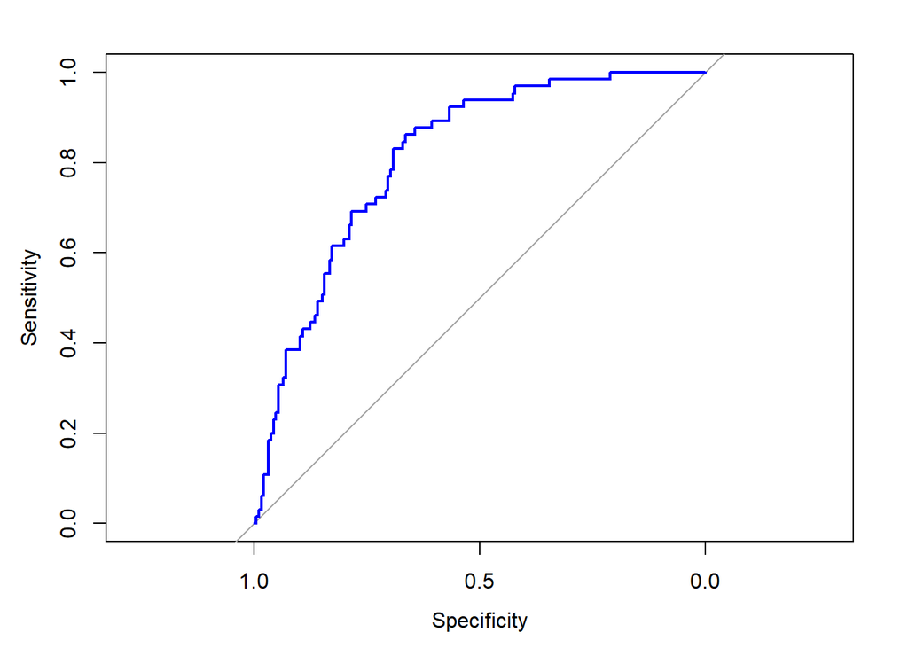

```r
best_log <- glm(formula = response ~ chk_acct + duration + credit_his + purpose + amount + present_emp + installment_rate + sex + other_debtor +  other_install+ foreign + n_credits + n_people, family = "binomial", data = train_german_credit)

train_prob <- predict(best_log, type = "response")

german_credit_prob <- predict(best_log, newdata = test_german_credit[,-21], type = "response")

ROC <- roc(test_german_credit$response,german_credit_prob)
plot(ROC, col = "blue")
```

```r
auc(ROC)
```

```
## Area under the curve: 0.8124
```

```r
cutoff_prob <- coords(ROC,"best",ret = "threshold")



german_credit_pred <- ifelse(german_credit_prob > cutoff_prob, 1, 0)
table(german_credit_pred,test_german_credit$response,
      dnn = list("predicted", "actual"))
```

```
##          actual
## predicted   0   1
##         0 123   9
##         1  62  56
```

#### Grid Search

##### Grid Search to determine optimal cut-off probability

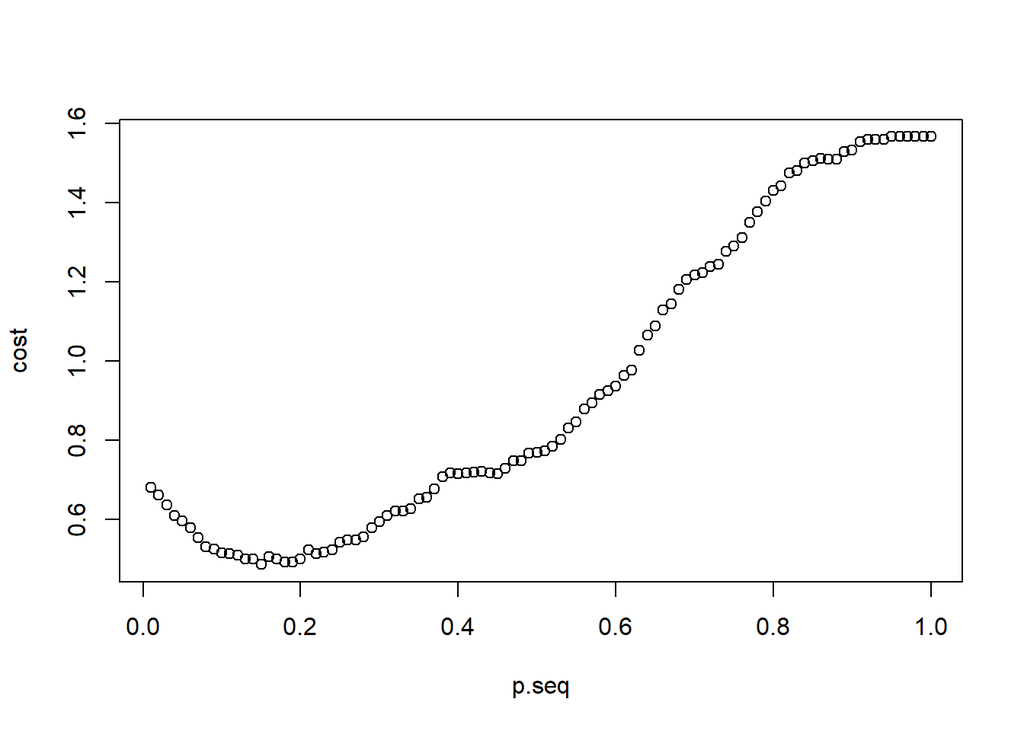

```r
costfunc <- function(obs, pred.p, pcut) {
  weight1 <- 5   # define the weight for "true=1 but pred=0" (FN)
  weight0 <- 1    # define the weight for "true=0 but pred=1" (FP)
  c1 <- (obs == 1) & (pred.p < pcut)    # count for "true=1 but pred=0"   (FN)
  c0 <- (obs == 0) & (pred.p >= pcut)   # count for "true=0 but pred=1"   (FP)
  cost <- mean(weight1 * c1 + weight0 * c0)  # misclassification with weight
  return(cost) # you have to return to a value when you write R functions
}

p.seq <- seq(0.01, 1, 0.01)

cost <- rep(0, length(p.seq))

for (i in 1:length(p.seq)) {
  cost[i] = costfunc(obs = train_german_credit$response,
                     pred.p = train_prob, pcut = p.seq[i])
}

plot(p.seq, cost)
```

```r
optimal.pcut.glm0 <- p.seq[which(cost == min(cost))]


german_credit_pred <- ifelse(german_credit_prob > optimal.pcut.glm0, 1, 0)
table(german_credit_pred,test_german_credit$response,
      dnn = list("predicted", "actual"))
```

```
##          actual
## predicted  0  1
##         0 95  4
##         1 90 61
```

#### Cross-Validation

##### Cross-Validation

```r
pcut <- optimal.pcut.glm0

costfunc2 <- function(obs, pred.p){
  weight1 <- 5   # define the weight for "true=1 but pred=0" (FN)
  weight0 <- 1    # define the weight for "true=0 but pred=1" (FP)
  c1 <- (obs == 1) & (pred.p < pcut)    # count for "true=1 but pred=0"   (FN)
  c0 <- (obs == 0) & (pred.p >= pcut)   # count for "true=0 but pred=1"   (FP)
  cost <- mean(weight1 * c1 + weight0 * c0)  # misclassification with weight
  return(cost) # you have to return to a value when you write R functions
}

credit_glm1 <- glm(response~. , family = binomial, data = german_credit)
cv.result <-  cv.glm(data = german_credit, glmfit = credit_glm1, cost = costfunc2, K = 4)
cv.result$delta[2]
```

```
## [1] 0.535
```

### Classification Tree

#### Out of Sample Prediction

##### Out of Sample Prediction

The misclassification rate (false negative rate) is **0.076** and is higher than that of the logistic regression model (**0.061**).

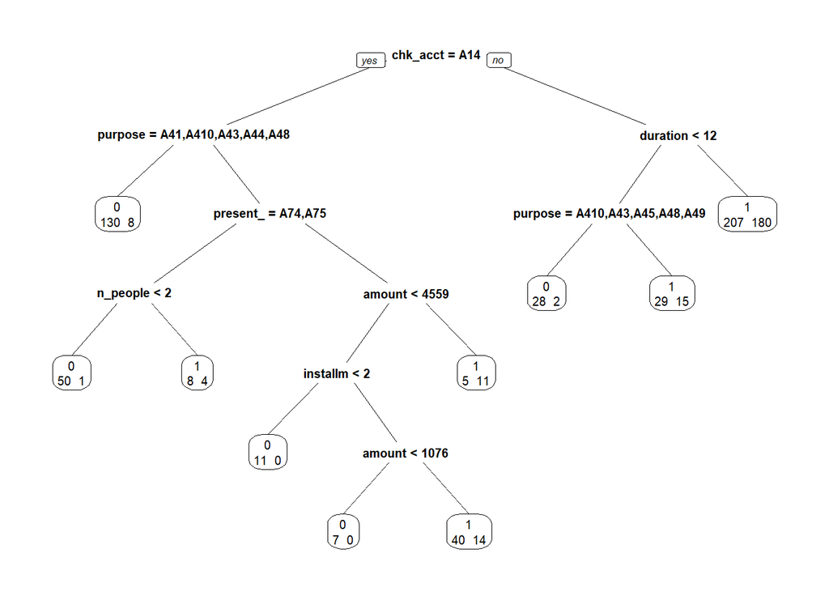

```r
tree_model <- rpart(formula = response ~ chk_acct + duration + credit_his + purpose +            amount + present_emp + installment_rate + sex + other_debtor +  other_install+            foreign + n_credits + n_people, data = train_german_credit, method = "class", parms = list(loss = matrix(c(0,5,1,0), nrow = 2)))



prp(tree_model, extra = 1)
```

```r
tree_predict <- predict(tree_model, test_german_credit[,-21], type = "class")


table(test_german_credit$response, tree_predict, dnn = c("Actual","Predicted"))
```

```
##       Predicted
## Actual   0   1
##      0  82 103
##      1   5  60
```

#### Cross-Validation

##### Cross-Validation

The misclassification rate (false negative rate) is **0.061** and is same as that of the logistic regression model.

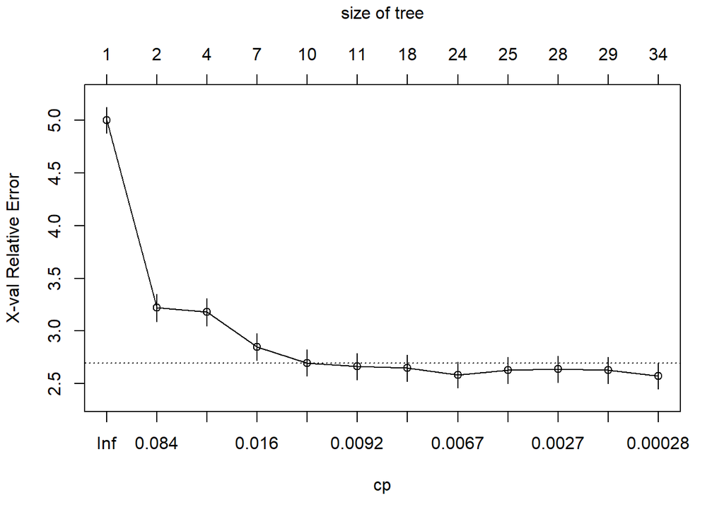

```r
credit_rpart <- rpart(formula = response ~ . , data = train_german_credit, method = "class",
                       parms = list(loss = matrix(c(0,5,1,0), nrow = 2)), cp = 0.0001)



plotcp(credit_rpart)
```

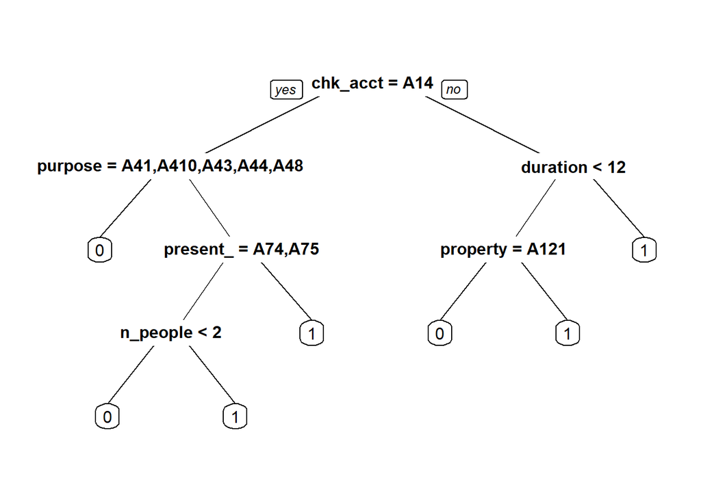

```r
prp(prune(credit_rpart, cp = 0.012)) # Pruning the tree
```

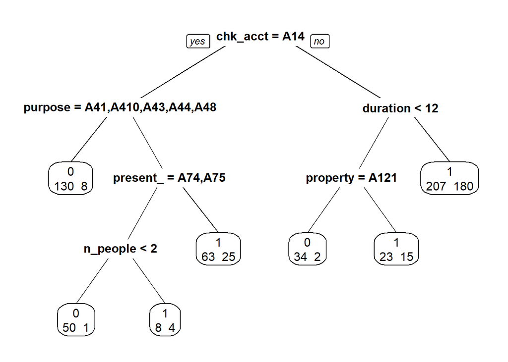

```r
credit_rpartbest <- rpart(formula = response ~ . , data = train_german_credit, method = "class",
                      parms = list(loss = matrix(c(0,5,1,0), nrow = 2)), cp = 0.012)

prp(credit_rpartbest, extra = 1)
```

```r
credit_testpredict <- predict(credit_rpartbest, test_german_credit[,-21], type = "class")


table(test_german_credit$response, credit_testpredict, dnn = c("Actual","Predicted"))
```

```
##       Predicted
## Actual   0   1
##      0  83 102
##      1   4  61
```